# BIOL301_Homework09

```python
import numpy as np
import scipy.optimize as opt
import scipy.stats as stats
from scipy.stats import norm

import matplotlib.pyplot as plt
import seaborn as sns
sns.set()
```

## Problem 1: Linear versus exponential growth

```python
areas = [460, 455, 460, 455, 470, 465, 464, 469, 471, 473, 475, 477, 483, 483,
         486, 492, 498, 501, 513, 515, 513, 511, 512, 508, 511, 515, 519, 525,
         528, 532, 536, 531, 536, 544, 548, 554, 561, 566, 570, 579, 580, 583,
         582, 586, 582, 588, 584, 591, 599, 596, 600, 607, 609, 613, 622, 630,
         638, 644, 648, 653, 657, 653, 652, 651, 657, 660, 657, 658, 663, 667,
         659, 659, 670, 677, 690, 701, 704, 711, 722, 723]
```

```python
times = np.arange(len(areas))
```

In recitation we fit an exponential growth curve to this function, and you should have gotten something like this below:

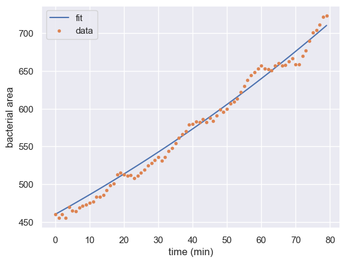

Let's now fit linear growth instead, where $A(t) = mt + b$.

## 1A.

Below plot a guess at what parameters for $m$ and $b$ might be reasonable for this data. Plot your guess at the fit and the data on the same plot.

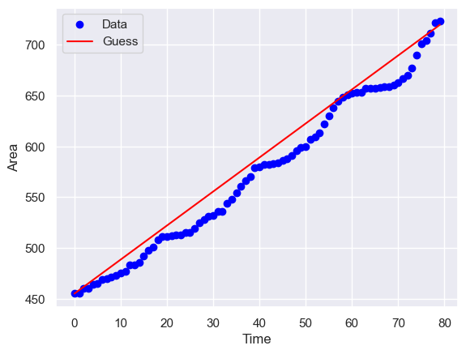

```python
#guessing m and b
areas.sort()
max = areas[-1]
min = areas[0]
m = (max-min)/len(times)
b = areas[0]

# plot the guess line
guess = []
for t in times:
    guess.append(m*t+b)

#plotting
plt.scatter(times, areas, label="Data", color="blue")
plt.plot(times, guess, label="Guess", color="red")
plt.xlabel("Time")
plt.ylabel("Area")
plt.legend()
plt.show()
```

## 1B.

Use `scipy.optimize` to fit the data for linear growth. For this, you will need to change the structure of the `chi_squared` function as well as your guess for your parameters.

```python
# chi-squared function
def chiSquare(params, x, y):
    m, b = params
    model = m * x + b
    # assume equal uncertainty (sigma=1)
    chi2 = np.sum((y - model)**2)
    return chi2

#initial guess
initGuess = [3,460]

#minimize
result = opt.minimize(chiSquare, initGuess, args=(times, areas))
m_fit, b_fit = result.x
print("Best-fit parameters:")
print("m =", m_fit)
print("b =", b_fit)
```

```
Best-fit parameters:
m = 3.321565814845744
b = 442.42315066152366
```

## 1C.

Plot the best linear fit over the data.

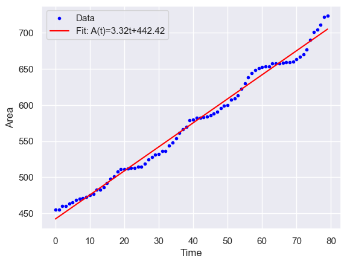

```python
#plot
plt.scatter(times, areas, label="Data", color="blue", marker = '.')
plt.plot(times, m_fit*times + b_fit, label=f"Fit: A(t)={m_fit:.2f}t+{b_fit:.2f}", color="red")
plt.xlabel("Time")
plt.ylabel("Area")
plt.legend()
plt.show()
```

## 1D.

From what you see, which do you think is a "better fit": linear or exponential growth? Explain your reasoning.

Without optimization, exponential growth seems to be a better fit as there is substantially more overlap in with the data points. However, after optimizing, linear growth has less deviation from the original data set, implying it is a better fit.

## Problem 2: Beware of the standard deviation (6 points)

Below I include some "mock data" that we will explore.

```python
mock_data = np.array([ 338, 189, 213, 2467, 518, 393, 1359, 399, 786,  106, 1452,
                      262, 239, 250, 444, 387, 396, 872, 11, 865, 220, 400, 68,
                      1136, 0, 25, 1186, 200, 870, 428, 1285, 791, 1172, 84, 672,
                      674, 642, 571, 329, 288, 402, 1405, 262, 164, 3099, 4497,
                      3785, 1543, 4152, 1645, 126, 1142, 1118, 408, 1723, 1677,
                      791, 896, 404, 167, 1502, 1451, 709, 796, 46, 631, 148,
                      1416, 2216, 1091, 179, 1308, 498, 1483, 643, 4927, 2146,
                      1864, 385, 198, 96, 900, 1848, 731, 1008, 1054, 799, 1318,
                      117, 24, 85, 3557, 159, 280, 271, 2693, 56, 2346, 33, 143])
```

## 2A.

Use `np.mean()` and `np.std()` to get the mean and standard deviation of the `mock_data`.

```python
mean = np.mean(mock_data)
stdDev = np.std(mock_data)

print(mean, stdDev)
```

```
935.48 1002.2061512483347
```

## 2B.

Now plot a histogram or ECDF of the `mock_data`. Do you think the mean and standard deviation are a meaningful way to describe the data? Why or why not?

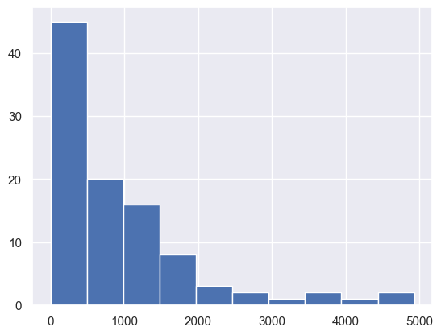

```python
plt.hist(mock_data)
plt.show()
```

No, because the mean favors the lower side of data, and the standard deviation is very large. With a range up to nearly 5000 and the most common numbers being less than 1000, the mean and standard deviation are not very helpful in assessing the data.

## 2C.

To drive the point home, use the mean and standard deviation from part A to plot the CDF of the corresponding normal distribution. For this, you can use `scipy.stats.norm.cdf(x, loc, scale)`, where `x` is a list or array of x-values you wish to get values for, `loc` is the mean, and `scale` is the standard deviation.

```python
print(min)
```

```
455
```

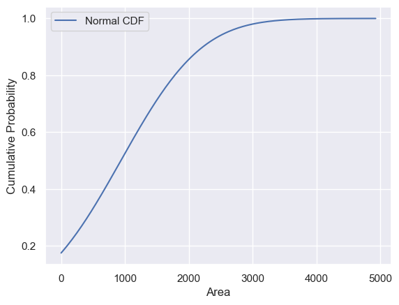

```python
# initializing variables
x = np.linspace(np.min(mock_data), np.max(mock_data), 200)

# Compute CDF
cdf_values = norm.cdf(x, loc=mean, scale=stdDev)

# Plot
plt.plot(x, cdf_values, label="Normal CDF")
plt.xlabel("Area")
plt.ylabel("Cumulative Probability")
plt.legend()
plt.show()
```

## 2D.

Plot this normal distribution CDF and the ECDF of the data on the same graph. Explain why the mean and standard deviation you originally found fail to describe this data well.

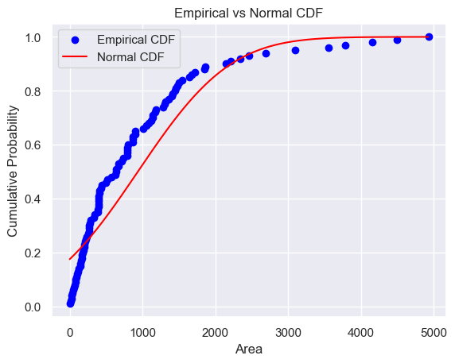

```python
# ECDF
sorted_data = np.sort(mock_data)
ecdf = np.arange(1, len(sorted_data)+1) / len(sorted_data)

# Plot
plt.scatter(sorted_data, ecdf, label="Empirical CDF", color="blue")
plt.plot(x, cdf_values, label="Normal CDF", color="red")
plt.xlabel("Area")
plt.ylabel("Cumulative Probability")
plt.title("Empirical vs Normal CDF")
plt.legend()
plt.show()
```

# Problem 3: The probability distributions for describing kinesin walking (7 points)

For this, we will be exploring the data from [this paper](https://www.science.org/doi/epdf/10.1126/science.1093753) that first established how kinease "walks" along microtubules. [This now iconic video](https://www.youtube.com/watch?v=y-uuk4Pr2i8&ab_channel=EmmanuelDumont) demonstrates what is now known about kinesin walking "hand-over-hand". You don't need to read the paper in full to follow the analysis below, but make sure to look at the figures.

In Figure 1A, the authors demonstrate the two possible mechanisms by which kinesin can walk along a microtubule. In the "hand-over-hand" model a given kinesin head would be expected 16 nm at a time, while in the "inchworm" model the kinesin head would move just 8 nm at a time.

## 3A.

From the data shown in Figure 2, which model of kinesin walking is better supported? Pay attention to the size of the "jumps" in position.

Based on the data shown in Figure 2 of the article, the hand over hand mechanism is better supported.

Now look at the data in Figure 3B. This data is best described by a [gamma distribution](https://docs.scipy.org/doc/scipy/reference/generated/scipy.stats.gamma.html) which is distribution that we have not yet talked about, but it has a simple story: it's the time it takes for multiple Poisson processes to occur. So for our kinesin walking, we are interested in the time it takes for **two steps** to occur, resulting in the kinesin head of interest moving forward.

Again, I include a reproduction of the data below.

```python
# x_values, times centered between 0 and 1/3, 1/3 and 2/3, etc.
bin_times = np.linspace(0, 8+2/3, 27) + 1/6

# y_values
bin_counts = [21, 40, 52, 57, 55, 44, 32, 22, 17, 12, 8, 8, 5, 2, 2, 3, 1, 2, 2, 1, 0, 1, 0, 1, 1, 0, 1]

wait_times = []

# construct the data, with the x values repeated an appropriate number of times
for x, y in zip(bin_times, bin_counts):
    wait_times += [x]*y

# look at the final array
wait_times = np.array(wait_times)
```

```python
bin_times
```

```
array([0.16666667, 0.5       , 0.83333333, 1.16666667, 1.5       ,
       1.83333333, 2.16666667, 2.5       , 2.83333333, 3.16666667,
       3.5       , 3.83333333, 4.16666667, 4.5       , 4.83333333,
       5.16666667, 5.5       , 5.83333333, 6.16666667, 6.5       ,
       6.83333333, 7.16666667, 7.5       , 7.83333333, 8.16666667,
       8.5       , 8.83333333])
```

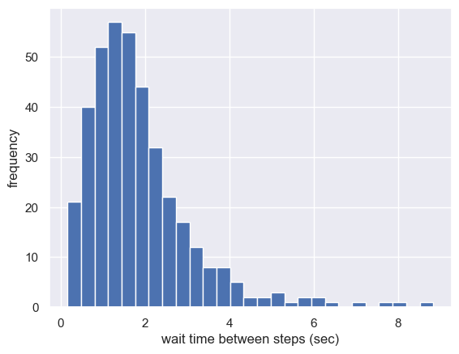

```python
plt.hist(wait_times,bins=27);
plt.xlabel("wait time between steps (sec)")
plt.ylabel("frequency");
```

We will fit this data to a gamma distribution. When using the `scipy.stats.gamma.cdf` function, the inputs will be as follows:

> `cdf(x, a, scale=???)`

where `x` are the x values for which we wish to get the corresponding CDF y values, `a` will be fixed to be 2 in this case for the two kinesin steps, and you will be fitting the `scale` parameters. The `scale` parameter here is defined as $1/\beta$, where $\beta$ is the rate at which the Poisson process occur.

## 3B.

To get a sense of a reasonable value for the `scale` parameter below, plot a "guess" at the fit, whit the gamma CDF plotted over the ECDF of the same.

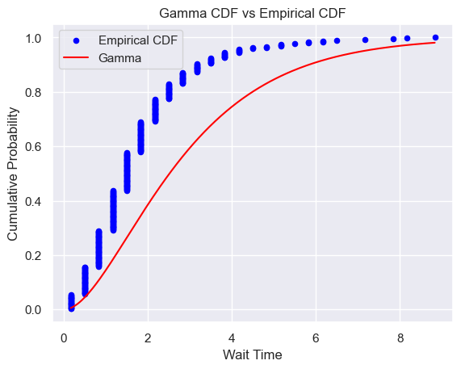

```python
# ecdf
sorted_data = np.sort(wait_times)
ecdf = np.arange(1, len(sorted_data)+1) / len(sorted_data)

#Gamma CDF guess
x = np.linspace(np.min(wait_times), np.max(wait_times), 200)
a = 2
scale_guess = 1.5
gamma_cdf = stats.gamma.cdf(x, a=a, scale=scale_guess)

# Step 3: Plot
plt.scatter(sorted_data, ecdf, s=20, marker='o', label="Empirical CDF", color="blue")
#plt.scatter(sorted_data, ecdf, s=15, marker='o')
plt.plot(x, gamma_cdf, label="Gamma", color="red")
plt.xlabel("Wait Time")
plt.ylabel("Cumulative Probability")
plt.title("Gamma CDF vs Empirical CDF")
plt.legend()
plt.show()
```

## 3C.

Write a chi-squared function for the gamma function below. You may want to make reference to the `chi_squared_normal` function from recitation for an example of how to write a chi-squared function for distributions.

```python
def chi_squared_gamma(params, data, ecdf):
    '''A function that creates a chi squared evaluation for a gamma distribution'''
    scale = params[0]
    a = 2
    # model CDF at the sorted data points
    model_cdf = stats.gamma.cdf(data, a=a, scale=scale)
    chi2 = np.sum((ecdf - model_cdf)**2)
    return chi2
```

## 3D.

Now optimize your chi-squared function to find the best value for `scale` for this data.

```python
#starting guess
init_guess = [1.5]

#minimize chi-squared
result = opt.minimize(chi_squared_gamma, init_guess, args=(sorted_data, ecdf))

#extract best-fit scale
best_scale = result.x[0]
print("Best-fit scale =", best_scale)
```

```
Best-fit scale = 0.8739443562689847
```

## 3E.

Validate that your fitting worked well by plotting the CDF fit over the ECDF data.

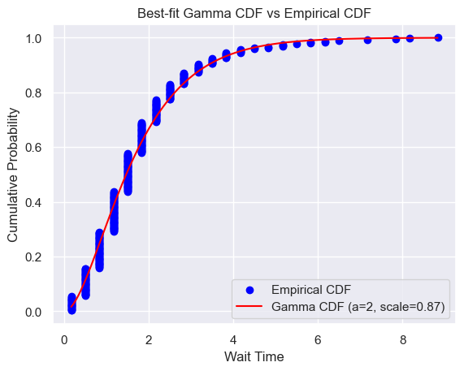

```python
#plot best-fit gamma CDF vs ECDF
best_gamma_cdf = stats.gamma.cdf(x, a=2, scale=best_scale)

plt.scatter(sorted_data, ecdf, label="Empirical CDF", color="blue")
plt.plot(x, best_gamma_cdf, label=f"Gamma CDF (a=2, scale={best_scale:.2f})", color="red")
plt.xlabel("Wait Time")
plt.ylabel("Cumulative Probability")
plt.title("Best-fit Gamma CDF vs Empirical CDF")
plt.legend()
plt.show()
```